# Final Project Code Appendix

## 0. Imports and Load Packages

```r
library(tidyverse)
library(lmtest)
library(sandwich)
library(scales)
```

## 1. Read and clean data

```r
salary <- read.table(
  "salary.txt",
  header = TRUE,
  sep = "",
  stringsAsFactors = FALSE,
  na.strings = "NA"
)

salary <- salary %>%
  mutate(
    sex = factor(sex, levels = c("M", "F")),
    deg = factor(deg),
    field = factor(field),
    rank = factor(rank, levels = c("Assist", "Assoc", "Full")),
    admin = factor(admin, levels = c(0, 1)),
    startyr = as.integer(startyr),
    year = as.integer(year),
    yrdeg = as.integer(yrdeg),
    salary = as.numeric(salary),
    experience = year - startyr
  )

# checks for problematic values (ensured no negative experience)
# salary %>%
  # filter(experience < 0) %>%
  # print()

salary_clean <- salary %>%
  filter(experience >= 0, !is.na(rank))
```

## 2.1 Exploratory Analysis Numerical Summaries

```r
salary_clean %>%
  count(sex, rank, field)
```

```
##    sex   rank field    n
## 1    M Assist  Arts  349
## 2    M Assist Other 1614
## 3    M Assist  Prof  625
## 4    M  Assoc  Arts  929
## 5    M  Assoc Other 3197
## 6    M  Assoc  Prof  938
## 7    M   Full  Arts  759
## 8    M   Full Other 5594
## 9    M   Full  Prof 1857
## 10   F Assist  Arts  319
## 11   F Assist Other 1012
## 12   F Assist  Prof  129
## 13   F  Assoc  Arts  300
## 14   F  Assoc Other 1032
## 15   F  Assoc  Prof  133
## 16   F   Full  Arts  183
## 17   F   Full Other  691
## 18   F   Full  Prof  127
```

```r
salary_clean %>%
  summarise(
    n_records = n(),
    n_people = n_distinct(id),
    min_year = min(year, na.rm = TRUE),
    max_year = max(year, na.rm = TRUE)
  ) %>%
  print()
```

```
##   n_records n_people min_year max_year
## 1     19788     1597       76       95
```

```r
# colour palette for sex used across all plots
sex_colours <- c("M" = "#4472C4", "F" = "#E05C5C")
```

## 2.2 Exploratory Analysis Plots

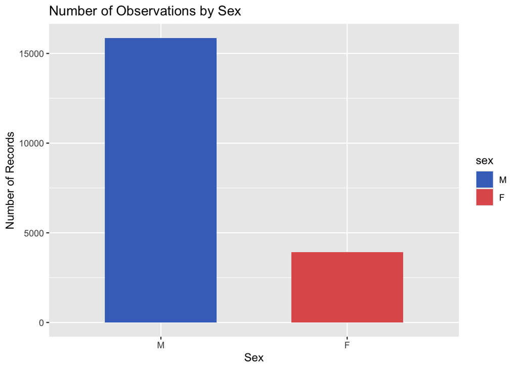

```r
salary_clean %>%
  count(sex) %>%
  ggplot(aes(x = sex, y = n, fill = sex)) +
  geom_col(width = 0.6) +
  scale_fill_manual(values = sex_colours) +
  labs(
    title = "Number of Observations by Sex",
    x = "Sex",
    y = "Number of Records"
  )
```

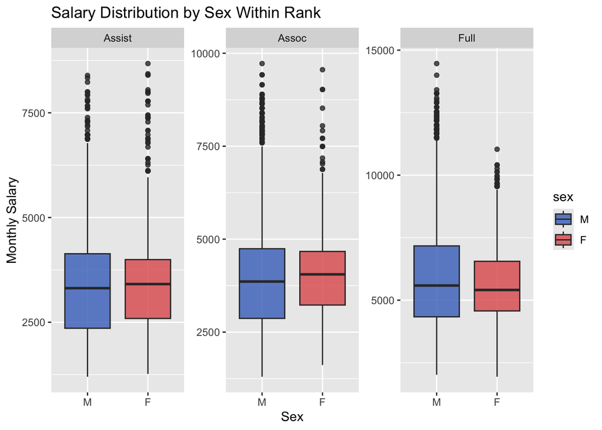

```r
ggplot(salary_clean, aes(x = sex, y = salary, fill = sex)) +
  geom_boxplot(alpha = 0.8) +
  scale_fill_manual(values = sex_colours) +
  facet_wrap(~ rank, scales = "free_y") +
  labs(
    title = "Salary Distribution by Sex Within Rank",
    x = "Sex",
    y = "Monthly Salary"
  )
```

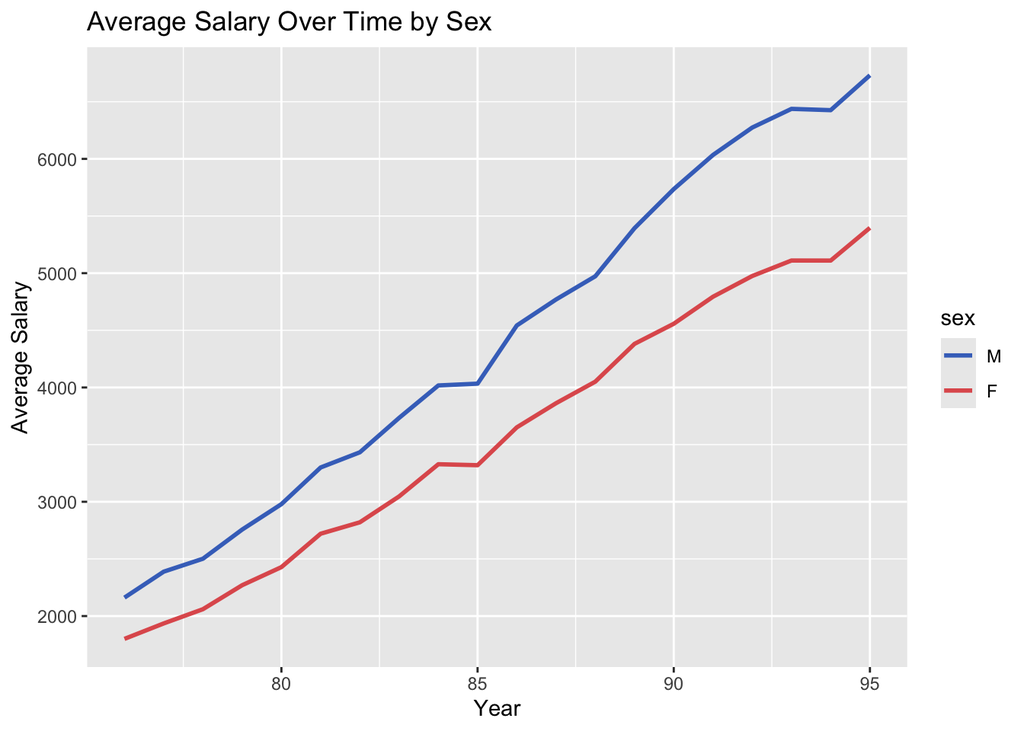

```r
salary_clean %>%
  group_by(year, sex) %>%
  summarise(mean_salary = mean(salary), .groups = "drop") %>%
  ggplot(aes(x = year, y = mean_salary, color = sex)) +
  geom_line(size = 1) +
  scale_color_manual(values = sex_colours) +
  labs(
    title = "Average Salary Over Time by Sex",
    x = "Year",
    y = "Average Salary"
  )
```

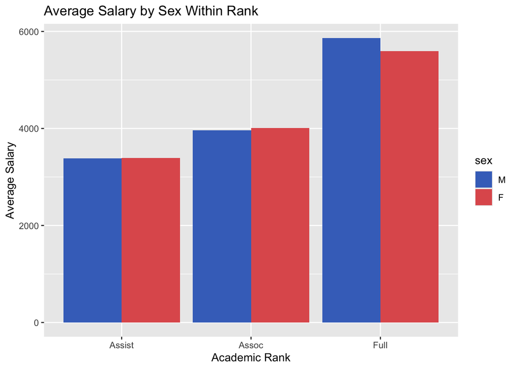

```r
salary_clean %>%
  group_by(rank, sex) %>%
  summarise(mean_salary = mean(salary), .groups = "drop") %>%
  ggplot(aes(x = rank, y = mean_salary, fill = sex)) +
  geom_col(position = "dodge") +
  scale_fill_manual(values = sex_colours) +
  labs(
    title = "Average Salary by Sex Within Rank",
    x = "Academic Rank",
    y = "Average Salary"
  )
```

## 3. Q1: Starting salary discrimination

```r
start_salary <- salary_clean %>%
  filter(year == startyr)

start_salary %>%
  summarise(
    n_records = n(),
    n_people = n_distinct(id)
  ) %>%
  print()
```

```
##   n_records n_people
## 1      1107     1107
```

```r
cat("\nRank distribution at hire:\n")
```

```
##
## Rank distribution at hire:
```

```r
start_salary %>%
  count(rank, sex) %>%
  arrange(rank, sex)
```

```
##     rank sex   n
## 1 Assist   M 501
## 2 Assist   F 301
## 3  Assoc   M 138
## 4  Assoc   F  38
## 5   Full   M 114
## 6   Full   F  15
```

```r
cat("\nStarting salary summaries by sex:\n")
```

```
##
## Starting salary summaries by sex:
```

```r
q1_summary <- start_salary %>%
  group_by(sex) %>%
  summarise(
    n = n(),
    mean_salary = mean(salary, na.rm = TRUE),
    median_salary = median(salary, na.rm = TRUE),
    sd_salary = sd(salary, na.rm = TRUE),
    iqr_salary = IQR(salary, na.rm = TRUE)
  )
print(q1_summary)
```

```
## # A tibble: 2 × 6
##   sex       n mean_salary median_salary sd_salary iqr_salary
##   <fct> <int>       <dbl>         <dbl>     <dbl>      <dbl>
## 1 M       753       4016.         3719      1933.       2076
## 2 F       354       3600.         3502.     1348.       1477
```

```r
cat("\nStarting salary summaries by sex and field:\n")
```

```
##
## Starting salary summaries by sex and field:
```

```r
start_salary %>%
  group_by(field, sex) %>%
  summarise(
    n = n(),
    mean_salary = mean(salary, na.rm = TRUE),
    median_salary = median(salary, na.rm = TRUE),
    .groups = "drop"
  )
```

```
## # A tibble: 6 × 5
##   field sex       n mean_salary median_salary
##   <fct> <fct> <int>       <dbl>         <dbl>
## 1 Arts  M        76       3137.         3029
## 2 Arts  F        71       3083.         3271
## 3 Other M       480       4048.         3721
## 4 Other F       247       3610.         3500
## 5 Prof  M       197       4276.         4043
## 6 Prof  F        36       4553.         4678.
```

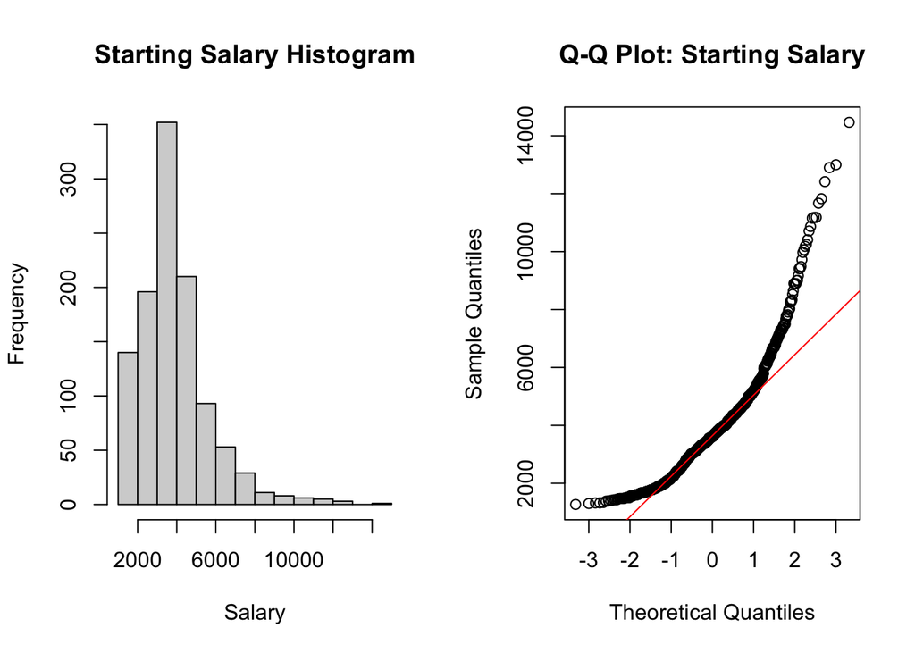

```r
par(mfrow = c(1, 2))
hist(start_salary$salary, main = "Starting Salary Histogram", xlab = "Salary")
qqnorm(start_salary$salary, main = "Q-Q Plot: Starting Salary")
qqline(start_salary$salary, col = "red")
```

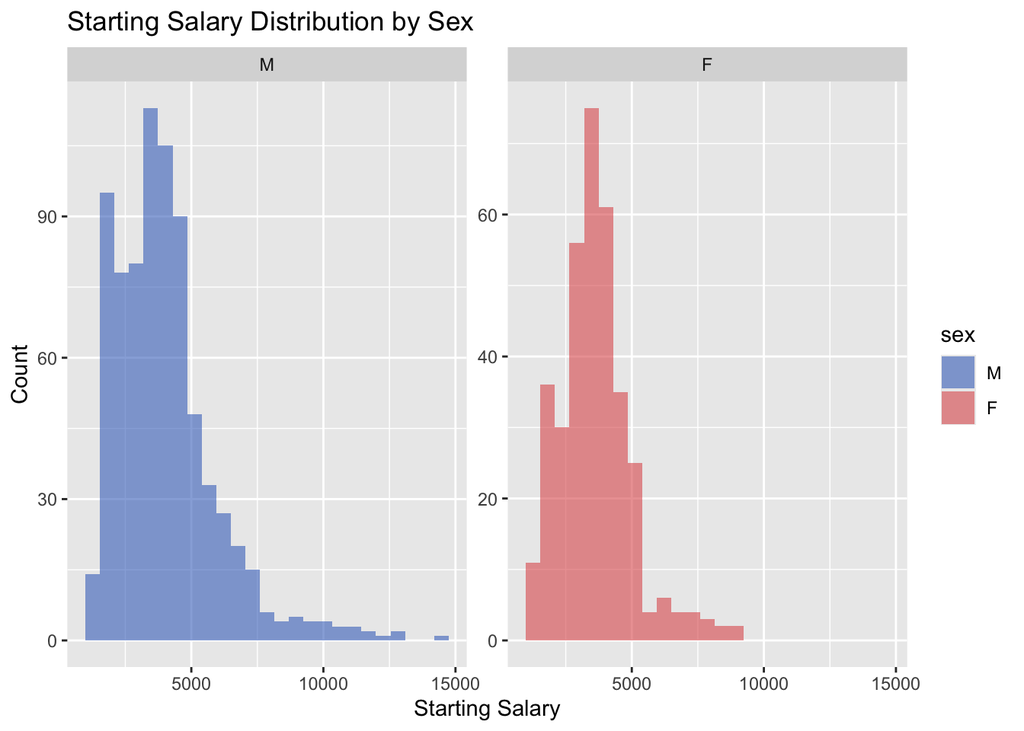

```r
par(mfrow = c(1, 1))

ggplot(start_salary, aes(x = salary, fill = sex)) +
  geom_histogram(alpha = 0.6, bins = 25, position = "identity") +
  scale_fill_manual(values = sex_colours) +
  facet_wrap(~ sex, scales = "free_y") +
  labs(
    title = "Starting Salary Distribution by Sex",
    x = "Starting Salary",
    y = "Count"
  )
```

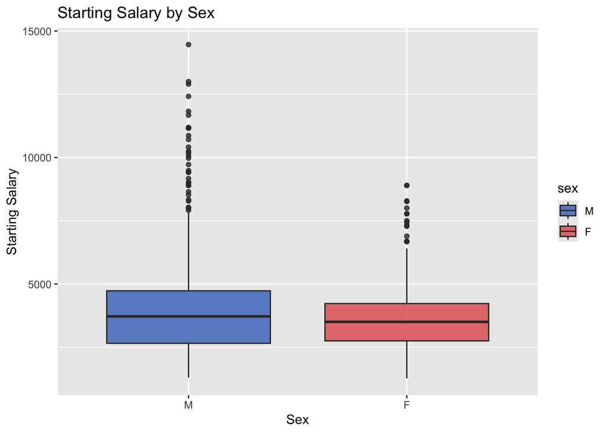

```r
ggplot(start_salary, aes(x = sex, y = salary, fill = sex)) +
  geom_boxplot(alpha = 0.8) +
  scale_fill_manual(values = sex_colours) +
  labs(
    title = "Starting Salary by Sex",
    x = "Sex",
    y = "Starting Salary"
  )
```

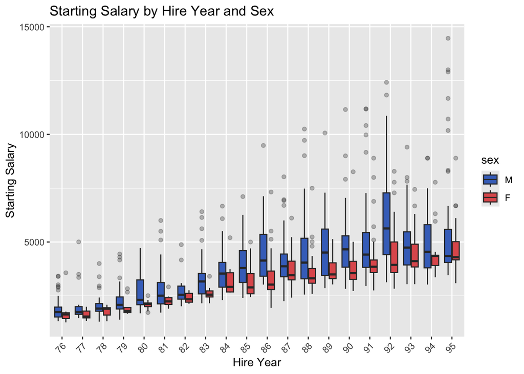

```r
ggplot(start_salary, aes(x = factor(startyr), y = salary, fill = sex)) +
  geom_boxplot(outlier.alpha = 0.3) +
  scale_fill_manual(values = sex_colours) +
  labs(
    title = "Starting Salary by Hire Year and Sex",
    x = "Hire Year",
    y = "Starting Salary"
  ) +
  theme(axis.text.x = element_text(angle = 45, hjust = 1))
```

```r
cat("\nQ1 Welch two-sample t-test:\n")
```

```
##
## Q1 Welch two-sample t-test:
```

```r
q1_ttest <- t.test(salary ~ sex, data = start_salary)
print(q1_ttest)
```

```
##
##  Welch Two Sample t-test
##
## data:  salary by sex
## t = 4.1326, df = 949.26, p-value = 3.904e-05
## alternative hypothesis: true difference in means between group M and group F is not equal to 0
## 95 percent confidence interval:
##  218.0416 612.4033
## sample estimates:
## mean in group M mean in group F
##        4015.545        3600.323
```

```r
q1_lm <- lm(salary ~ sex + field + yrdeg + startyr, data = start_salary)
cat("\nQ1 linear regression on raw salary:\n")
```

```
##
## Q1 linear regression on raw salary:
```

```r
summary(q1_lm)
```

```
##
## Call:
## lm(formula = salary ~ sex + field + yrdeg + startyr, data = start_salary)
##
## Residuals:
##     Min      1Q  Median      3Q     Max
## -4903.7  -524.8   -64.5   373.0  5723.9
##
## Coefficients:
##               Estimate Std. Error t value Pr(>|t|)
## (Intercept) -12782.653    524.223 -24.384  < 2e-16 ***
## sexF          -291.212     75.145  -3.875 0.000113 ***
## fieldOther     483.298    101.327   4.770 2.09e-06 ***
## fieldProf     1122.489    119.575   9.387  < 2e-16 ***
## yrdeg         -113.564      5.033 -22.562  < 2e-16 ***
## startyr        292.127      7.297  40.032  < 2e-16 ***
## ---
## Signif. codes:  0 '***' 0.001 '**' 0.01 '*' 0.05 '.' 0.1 ' ' 1
##
## Residual standard error: 1112 on 1101 degrees of freedom
## Multiple R-squared:  0.6103, Adjusted R-squared:  0.6085
## F-statistic: 344.9 on 5 and 1101 DF,  p-value: < 2.2e-16
```

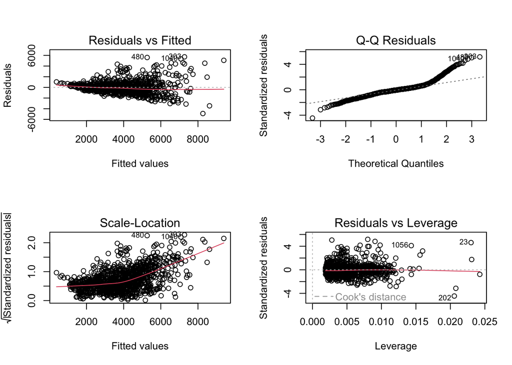

```r
par(mfrow = c(2, 2))
plot(q1_lm)
```

```r
par(mfrow = c(1, 1))

cat("\nQ1 regression with heteroskedasticity-robust SE:\n")
```

```
##
## Q1 regression with heteroskedasticity-robust SE:
```

```r
coeftest(q1_lm, vcov = vcovHC(q1_lm, type = "HC1"))
```

```
##
## t test of coefficients:
##
##                Estimate  Std. Error  t value  Pr(>|t|)
## (Intercept) -12782.6525    475.8501 -26.8628 < 2.2e-16 ***
## sexF          -291.2120     67.2647  -4.3293 1.632e-05 ***
## fieldOther     483.2976     64.3585   7.5095 1.224e-13 ***
## fieldProf     1122.4886     92.0407  12.1956 < 2.2e-16 ***
## yrdeg         -113.5642      9.0566 -12.5394 < 2.2e-16 ***
## startyr        292.1267     11.4246  25.5699 < 2.2e-16 ***
## ---
## Signif. codes:  0 '***' 0.001 '**' 0.01 '*' 0.05 '.' 0.1 ' ' 1
```

```r
# Log salary model
start_salary <- start_salary %>%
  mutate(log_salary = log(salary))

q1_lm_log <- lm(log_salary ~ sex + field + yrdeg + startyr, data = start_salary)
cat("\nQ1 linear regression on log salary:\n")
```

```
##
## Q1 linear regression on log salary:
```

```r
summary(q1_lm_log)
```

```
##
## Call:
## lm(formula = log_salary ~ sex + field + yrdeg + startyr, data = start_salary)
##
## Residuals:
##      Min       1Q   Median       3Q      Max
## -0.99931 -0.14216 -0.00468  0.13354  0.79366
##
## Coefficients:
##              Estimate Std. Error t value Pr(>|t|)
## (Intercept)  3.308369   0.109199  30.297  < 2e-16 ***
## sexF        -0.073436   0.015653  -4.691 3.05e-06 ***
## fieldOther   0.132527   0.021107   6.279 4.90e-10 ***
## fieldProf    0.278076   0.024908  11.164  < 2e-16 ***
## yrdeg       -0.022434   0.001049 -21.396  < 2e-16 ***
## startyr      0.075468   0.001520  49.648  < 2e-16 ***
## ---
## Signif. codes:  0 '***' 0.001 '**' 0.01 '*' 0.05 '.' 0.1 ' ' 1
##
## Residual standard error: 0.2316 on 1101 degrees of freedom
## Multiple R-squared:  0.7096, Adjusted R-squared:  0.7083
## F-statistic: 538.1 on 5 and 1101 DF,  p-value: < 2.2e-16
```

```r
cat("\nQ1 log-salary regression with robust SE:\n")
```

```
##
## Q1 log-salary regression with robust SE:
```

```r
coeftest(q1_lm_log, vcov = vcovHC(q1_lm_log, type = "HC1"))
```

```
##
## t test of coefficients:
##
##               Estimate Std. Error  t value  Pr(>|t|)
## (Intercept)  3.3083687  0.1052231  31.4415 < 2.2e-16 ***
## sexF        -0.0734358  0.0147648  -4.9737 7.615e-07 ***
## fieldOther   0.1325275  0.0150057   8.8318 < 2.2e-16 ***
## fieldProf    0.2780760  0.0203659  13.6540 < 2.2e-16 ***
## yrdeg       -0.0224342  0.0014548 -15.4211 < 2.2e-16 ***
## startyr      0.0754680  0.0018171  41.5316 < 2.2e-16 ***
## ---
## Signif. codes:  0 '***' 0.001 '**' 0.01 '*' 0.05 '.' 0.1 ' ' 1
```

```r
q1_log_coef <- coef(q1_lm_log)["sexF"]
cat("\nApproximate percent difference for women in starting salary:\n")
```

```
##
## Approximate percent difference for women in starting salary:
```

```r
cat(round((exp(q1_log_coef) - 1) * 100, 2), "%\n")
```

```
## -7.08 %
```

## 4a. Q2: Wage difference at promotion

```r
promotion_data <- salary_clean %>%
  arrange(id, year) %>%
  group_by(id) %>%
  mutate(
    prev_rank = lag(rank),
    prev_salary = lag(salary),
    prev_year = lag(year)
  ) %>%
  ungroup() %>%
  filter(prev_rank == "Assoc", rank == "Full")

promotion_data %>%
  summarise(
    n_promotions = n(),
    n_people = n_distinct(id)
  ) %>%
  print()
```

```
## # A tibble: 1 × 2
##   n_promotions n_people
##          <int>    <int>
## 1          547      547
```

```r
promotion_data <- promotion_data %>%
  group_by(id) %>%
  slice(1) %>%
  ungroup()
```

```r
promotion_data <- promotion_data %>%
  mutate(
    raise_amount = salary - prev_salary,
    raise_pct = (salary - prev_salary) / prev_salary
  )

cat("\nPromotion raise summaries by sex:\n")
```

```
##
## Promotion raise summaries by sex:
```

```r
promotion_data %>%
  group_by(sex) %>%
  summarise(
    n = n(),
    mean_raise = mean(raise_amount, na.rm = TRUE),
    median_raise = median(raise_amount, na.rm = TRUE),
    mean_pct_raise = mean(raise_pct, na.rm = TRUE),
    median_pct_raise = median(raise_pct, na.rm = TRUE),
    .groups = "drop"
  ) %>%
  print()
```

```
## # A tibble: 2 × 6
##   sex       n mean_raise median_raise mean_pct_raise median_pct_raise
##   <fct> <int>      <dbl>        <dbl>          <dbl>            <dbl>
## 1 M       447       470.          363          0.124            0.101
## 2 F       100       517.          446          0.129            0.105
```

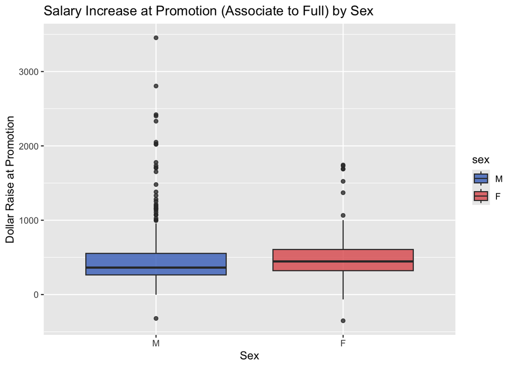

```r
ggplot(promotion_data, aes(x = sex, y = raise_amount, fill = sex)) +
  geom_boxplot(alpha = 0.8) +
  scale_fill_manual(values = sex_colours) +
  labs(
    title = "Salary Increase at Promotion (Associate to Full) by Sex",
    x = "Sex",
    y = "Dollar Raise at Promotion"
  )
```

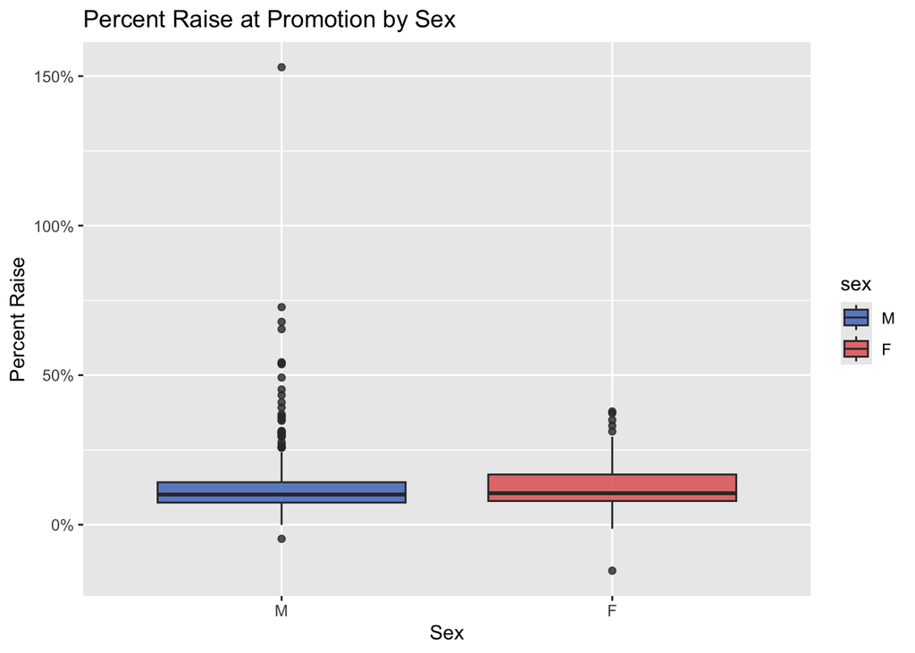

```r
ggplot(promotion_data, aes(x = sex, y = raise_pct, fill = sex)) +
  geom_boxplot(alpha = 0.8) +
  scale_fill_manual(values = sex_colours) +
  scale_y_continuous(labels = percent_format(accuracy = 1)) +
  labs(
    title = "Percent Raise at Promotion by Sex",
    x = "Sex",
    y = "Percent Raise"
  )
```

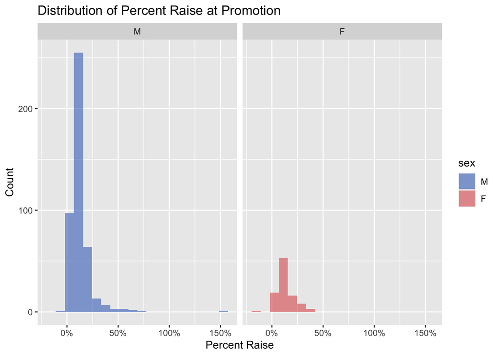

```r
ggplot(promotion_data, aes(x = raise_pct, fill = sex)) +
  geom_histogram(alpha = 0.6, bins = 20, position = "identity") +
  scale_fill_manual(values = sex_colours) +
  facet_wrap(~ sex) +
  scale_x_continuous(labels = percent_format(accuracy = 1)) +
  labs(
    title = "Distribution of Percent Raise at Promotion",
    x = "Percent Raise",
    y = "Count"
  )
```

```r
cat("\nQ2 Welch t-test for dollar raise:\n")
```

```
##
## Q2 Welch t-test for dollar raise:
```

```r
print(t.test(raise_amount ~ sex, data = promotion_data))
```

```
##
##  Welch Two Sample t-test
##
## data:  raise_amount by sex
## t = -1.1385, df = 155.45, p-value = 0.2566
## alternative hypothesis: true difference in means between group M and group F is not equal to 0
## 95 percent confidence interval:
##  -127.73859   34.32727
## sample estimates:
## mean in group M mean in group F
##        469.9813        516.6870
```

```r
cat("\nQ2 Welch t-test for percent raise:\n")
```

```
##
## Q2 Welch t-test for percent raise:
```

```r
print(t.test(raise_pct ~ sex, data = promotion_data))
```

```
##
##  Welch Two Sample t-test
##
## data:  raise_pct by sex
## t = -0.45167, df = 182.87, p-value = 0.652
## alternative hypothesis: true difference in means between group M and group F is not equal to 0
## 95 percent confidence interval:
##  -0.02508576  0.01573983
## sample estimates:
## mean in group M mean in group F
##        0.124312        0.128985
```

```r
cat("\nQ2 Wilcoxon test for percent raise:\n")
```

```
##
## Q2 Wilcoxon test for percent raise:
```

```r
print(wilcox.test(raise_pct ~ sex, data = promotion_data))
```

```
##
##  Wilcoxon rank sum test with continuity correction
##
## data:  raise_pct by sex
## W = 20318, p-value = 0.155
## alternative hypothesis: true location shift is not equal to 0
```

```r
q2_lm_raise <- lm(
  raise_amount ~ sex + field + yrdeg + prev_salary,
  data = promotion_data
)
cat("\nQ2 regression for dollar raise:\n")
```

```
##
## Q2 regression for dollar raise:
```

```r
summary(q2_lm_raise)
```

```
##
## Call:
## lm(formula = raise_amount ~ sex + field + yrdeg + prev_salary,
##     data = promotion_data)
##
## Residuals:
##      Min       1Q   Median       3Q      Max
## -1052.51  -191.06   -77.61    83.92  3059.16
##
## Coefficients:
##               Estimate Std. Error t value Pr(>|t|)
## (Intercept) -6.858e+02  2.296e+02  -2.987  0.00295 **
## sexF         2.586e+01  4.282e+01   0.604  0.54612
## fieldOther  -8.941e+01  4.768e+01  -1.875  0.06128 .
## fieldProf    1.250e+00  5.730e+01   0.022  0.98261
## yrdeg        1.675e+01  3.629e+00   4.616 4.89e-06 ***
## prev_salary -1.156e-03  1.574e-02  -0.073  0.94150
## ---
## Signif. codes:  0 '***' 0.001 '**' 0.01 '*' 0.05 '.' 0.1 ' ' 1
##
## Residual standard error: 377.3 on 541 degrees of freedom
## Multiple R-squared:  0.07412,    Adjusted R-squared:  0.06556
## F-statistic: 8.661 on 5 and 541 DF,  p-value: 6.54e-08
```

```r
cat("\nQ2 regression for dollar raise with robust SE:\n")
```

```
##
## Q2 regression for dollar raise with robust SE:
```

```r
coeftest(q2_lm_raise, vcov = vcovHC(q2_lm_raise, type = "HC1"))
```

```
##
## t test of coefficients:
##
##                Estimate  Std. Error t value  Pr(>|t|)
## (Intercept) -685.789742  233.807443 -2.9331  0.003498 **
## sexF          25.860075   40.355920  0.6408  0.521924
## fieldOther   -89.409015   48.342644 -1.8495  0.064933 .
## fieldProf      1.249621   61.724909  0.0202  0.983855
## yrdeg         16.752126    3.920405  4.2731 2.278e-05 ***
## prev_salary   -0.001156    0.015454 -0.0748  0.940400
## ---
## Signif. codes:  0 '***' 0.001 '**' 0.01 '*' 0.05 '.' 0.1 ' ' 1
```

```r
q2_lm_pct <- lm(
  raise_pct ~ sex + field + yrdeg + prev_salary,
  data = promotion_data
)
cat("\nQ2 regression for percent raise:\n")
```

```
##
## Q2 regression for percent raise:
```

```r
summary(q2_lm_pct)
```

```
##
## Call:
## lm(formula = raise_pct ~ sex + field + yrdeg + prev_salary, data = promotion_data)
##
## Residuals:
##      Min       1Q   Median       3Q      Max
## -0.27621 -0.05158 -0.02007  0.02561  1.37505
##
## Coefficients:
##               Estimate Std. Error t value Pr(>|t|)
## (Intercept) -4.893e-02  6.478e-02  -0.755   0.4504
## sexF         2.302e-03  1.208e-02   0.191   0.8489
## fieldOther  -2.593e-02  1.345e-02  -1.928   0.0543 .
## fieldProf   -1.316e-03  1.616e-02  -0.081   0.9351
## yrdeg        4.190e-03  1.024e-03   4.093 4.90e-05 ***
## prev_salary -2.828e-05  4.442e-06  -6.366 4.13e-10 ***
## ---
## Signif. codes:  0 '***' 0.001 '**' 0.01 '*' 0.05 '.' 0.1 ' ' 1
##
## Residual standard error: 0.1064 on 541 degrees of freedom
## Multiple R-squared:  0.07925,    Adjusted R-squared:  0.07074
## F-statistic: 9.313 on 5 and 541 DF,  p-value: 1.6e-08
```

```r
cat("\nQ2 regression for percent raise with robust SE:\n")
```

```
##
## Q2 regression for percent raise with robust SE:
```

```r
coeftest(q2_lm_pct, vcov = vcovHC(q2_lm_pct, type = "HC1"))
```

```
##
## t test of coefficients:
##
##                Estimate  Std. Error t value  Pr(>|t|)
## (Intercept) -4.8927e-02  5.7037e-02 -0.8578   0.39138
## sexF         2.3017e-03  1.0238e-02  0.2248   0.82220
## fieldOther  -2.5934e-02  1.3012e-02 -1.9930   0.04676 *
## fieldProf   -1.3165e-03  1.6098e-02 -0.0818   0.93485
## yrdeg        4.1904e-03  9.8829e-04  4.2401 2.628e-05 ***
## prev_salary -2.8276e-05  4.7286e-06 -5.9799 4.059e-09 ***
## ---
## Signif. codes:  0 '***' 0.001 '**' 0.01 '*' 0.05 '.' 0.1 ' ' 1
```

### 4b. Q2: Promotion Rates and Within-Rank Wage Gaps

This section investigates whether there are gender differences in promotion rates from Associate Professor to Full Professor, as well as differences in salary within academic ranks. Specifically, we examine (1) whether men and women are promoted to Full Professor at different rates, (2) how long faculty spend as Associate Professors before promotion, and (3) whether women earn systematically different salaries within the Associate and Full ranks after controlling for relevant characteristics.

#### Method

We first construct a **person-level dataset** restricted to faculty who have ever held the rank of Associate Professor. For each individual, we identify whether they were eventually promoted to Full Professor, the year they first became an Associate Professor, and the year they were first promoted to Full Professor (if applicable). We also compute the number of years spent as an Associate Professor before promotion. Additionally, we record salary at Associate entry, the last Associate salary, and the salary at entry into the Full Professor rank.

This person-level dataset allows us to compare promotion outcomes and salary changes across individuals.

```r
# build person-level dataset restricted to ever-Associate faculty
ever_assoc_ids <- salary_clean %>%
  group_by(id) %>%
  filter(any(rank == "Assoc")) %>%
  pull(id) %>%
  unique()

person_level <- salary_clean %>%
  filter(id %in% ever_assoc_ids) %>%
  arrange(id, year) %>%
  group_by(id) %>%
  summarise(
    sex             = first(sex),
    deg             = first(deg),
    field           = first(field),
    yrdeg           = first(yrdeg),
    promoted        = as.integer(any(rank == "Full")),
    yr_first_assoc  = min(year[rank == "Assoc"], na.rm = TRUE),
    yr_first_full   = ifelse(any(rank == "Full"),
                             min(year[rank == "Full"], na.rm = TRUE), NA_real_),
    yrs_as_assoc    = ifelse(any(rank == "Full"),
                             yr_first_full - yr_first_assoc, NA_real_),
    sal_assoc_entry = salary[rank == "Assoc"][which.min(year[rank == "Assoc"])],
    sal_assoc_last  = salary[rank == "Assoc"][which.max(year[rank == "Assoc"])],
    sal_full_entry  = ifelse(any(rank == "Full"),
                             salary[rank == "Full"][which.min(year[rank == "Full"])],
                             NA_real_),
    .groups = "drop"
  )
```

#### Promotion Rates by Sex

We first compare promotion rates between men and women by computing the proportion of Associate Professors who were eventually promoted to Full Professor by the end of the observation period.

```r
cat("Promotion rates by sex:\n")
```

```
## Promotion rates by sex:
```

```r
person_level %>%
  group_by(sex) %>%
  summarise(
    n          = n(),
    n_promoted = sum(promoted),
    pct        = round(100 * mean(promoted), 1),
    .groups = "drop"
  ) %>%
  print()
```

```
## # A tibble: 2 × 4
##   sex       n n_promoted   pct
##   <fct> <int>      <int> <dbl>
## 1 M       746        447  59.9
## 2 F       238        100  42
```

```r
ct <- table(Sex = person_level$sex, Promoted = person_level$promoted)
colnames(ct) <- c("Not Promoted", "Promoted")
cat("\nContingency table:\n")
```

```
##
## Contingency table:
```

```r
print(ct)
```

```
##    Promoted
## Sex Not Promoted Promoted
##   M          299      447
##   F          138      100
```

```r
cat("\nRow proportions:\n")
```

```
##
## Row proportions:
```

```r
print(round(prop.table(ct, margin = 1), 3))
```

```
##    Promoted
## Sex Not Promoted Promoted
##   M        0.401    0.599
##   F        0.580    0.420
```

```r
cat("\nMedian time as Associate before promotion:\n")
```

```
##
## Median time as Associate before promotion:
```

```r
person_level %>%
  filter(promoted == 1) %>%
  group_by(sex) %>%
  summarise(median_yrs = median(yrs_as_assoc, na.rm = TRUE), .groups = "drop") %>%
  print()
```

```
## # A tibble: 2 × 2
##   sex   median_yrs
##   <fct>      <dbl>
## 1 M              5
## 2 F              6
```

#### Observations

The results show that 59.9% of male Associate Professors were promoted to Full Professor, compared to 42.0% of female Associate Professors. The contingency table indicates that 447 of 746 men were promoted, while only 100 of 238 women were promoted.

Examining row proportions shows that about 60% of men were promoted compared to 42% of women, suggesting a substantial gender gap in promotion outcomes.

Among those who were promoted, the median time spent as an Associate Professor was 5 years for men and 6 years for women, indicating that women tend to remain in the Associate rank slightly longer before promotion.

#### Visualization of Promotion and Salary Patterns

To better understand these patterns, we visualize promotion rates, entry salaries at the Associate rank, salary gains upon promotion, and the distribution of time spent as an Associate Professor.

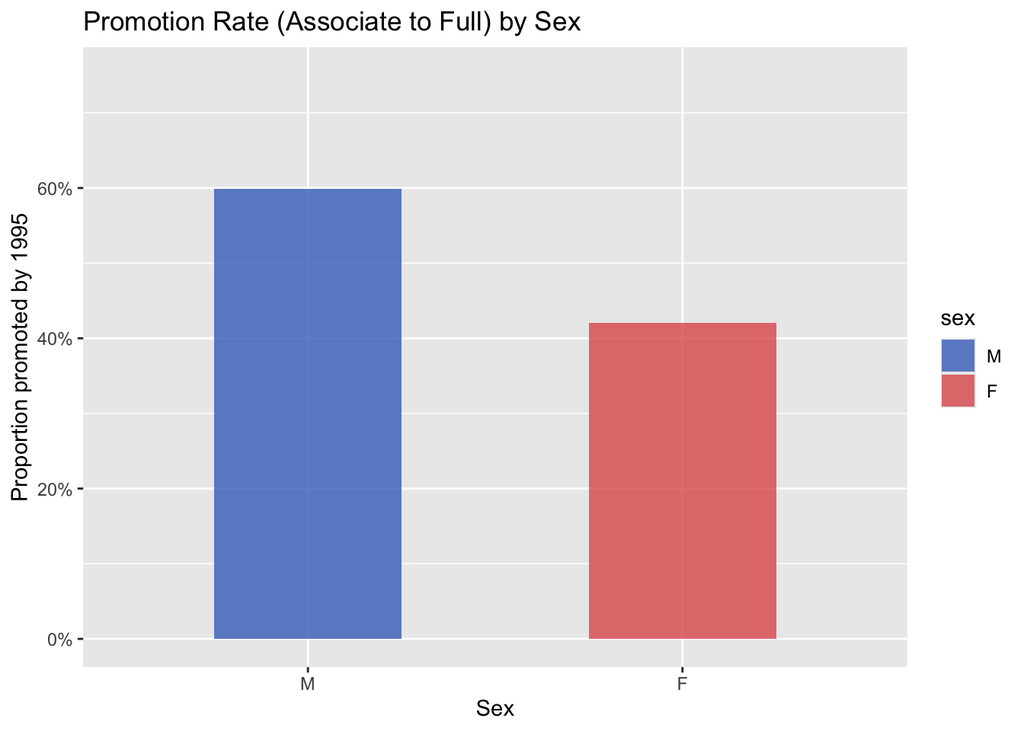

```r
# promotion rate bar chart
ggplot(person_level %>% group_by(sex) %>% summarise(pct = mean(promoted)),
       aes(x = sex, y = pct, fill = sex)) +
  geom_col(width = 0.5, alpha = 0.8) +
  scale_fill_manual(values = sex_colours) +
  scale_y_continuous(labels = percent_format(accuracy = 1), limits = c(0, 0.75)) +
  labs(title = "Promotion Rate (Associate to Full) by Sex",
       x = "Sex", y = "Proportion promoted by 1995")
```

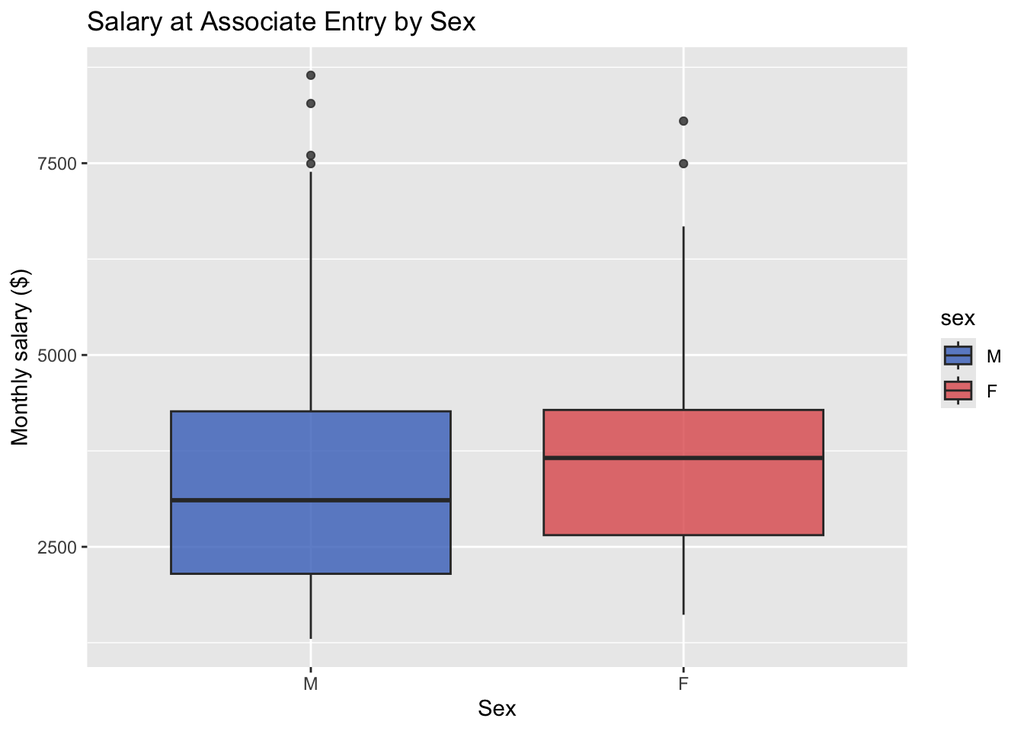

```r
# salary at Associate entry by sex
ggplot(person_level, aes(x = sex, y = sal_assoc_entry, fill = sex)) +
  geom_boxplot(alpha = 0.8) +
  scale_fill_manual(values = sex_colours) +
  labs(title = "Salary at Associate Entry by Sex",
       x = "Sex", y = "Monthly salary ($)")
```

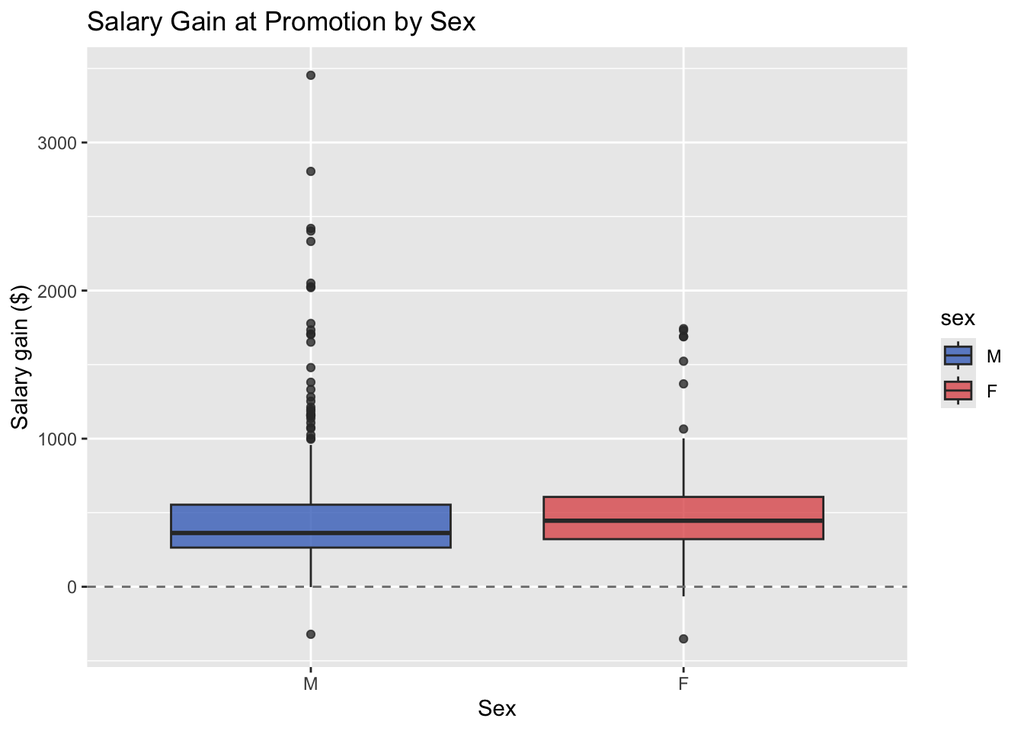

```r
# salary gain at promotion by sex
ggplot(person_level %>% filter(promoted == 1) %>%
         mutate(sal_gain = sal_full_entry - sal_assoc_last),
       aes(x = sex, y = sal_gain, fill = sex)) +
  geom_boxplot(alpha = 0.8) +
  scale_fill_manual(values = sex_colours) +
  geom_hline(yintercept = 0, linetype = "dashed", colour = "grey50") +
  labs(title = "Salary Gain at Promotion by Sex",
       x = "Sex", y = "Salary gain ($)")
```

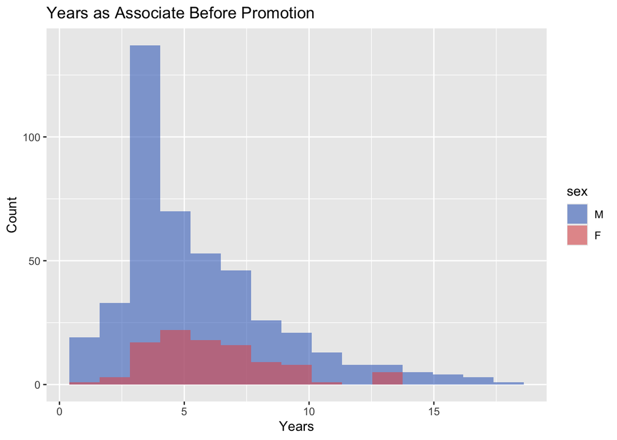

```r
# time as Associate before promotion
ggplot(person_level %>% filter(promoted == 1),
       aes(x = yrs_as_assoc, fill = sex)) +
  geom_histogram(alpha = 0.6, bins = 15, position = "identity") +
  scale_fill_manual(values = sex_colours) +
  labs(title = "Years as Associate Before Promotion",
       x = "Years", y = "Count")
```

#### Statistical Test for Differences in Promotion Rates To formally test whether the difference in promotion rates between men and women is statistically significant, we conduct a two-sample z-test for the difference in proportions. This test evaluates the null hypothesis that the promotion probability is the same for men and women.

```r
# two-sample z-test for difference in promotion proportions
nF <- sum(person_level$sex == "F")
nM <- sum(person_level$sex == "M")
kF <- sum(person_level$sex == "F" & person_level$promoted == 1)
kM <- sum(person_level$sex == "M" & person_level$promoted == 1)
pF <- kF / nF
pM <- kM / nM

p_pool <- (kF + kM) / (nF + nM)
se_z   <- sqrt(p_pool * (1 - p_pool) * (1/nF + 1/nM))
z_stat <- (pF - pM) / se_z
p_val  <- 2 * pnorm(-abs(z_stat))

se_diff <- sqrt(pF*(1-pF)/nF + pM*(1-pM)/nM)
ci_lo   <- (pF - pM) - 1.96 * se_diff
ci_hi   <- (pF - pM) + 1.96 * se_diff

cat(sprintf("pF = %.4f  (%d/%d)\n", pF, kF, nF))
```

```
## pF = 0.4202  (100/238)
```

```r
cat(sprintf("pM = %.4f  (%d/%d)\n", pM, kM, nM))
```

```
## pM = 0.5992  (447/746)
```

```r
cat(sprintf("Difference pF - pM = %+.4f\n", pF - pM))
```

```
## Difference pF - pM = -0.1790
```

```r
cat(sprintf("95%% CI: (%.4f, %.4f)\n", ci_lo, ci_hi))
```

```
## 95% CI: (-0.2509, -0.1071)
```

```r
cat(sprintf("z = %.3f,  p = %.4f\n", z_stat, p_val))
```

```
## z = -4.840,  p = 0.0000
```

```r
cat("\nEquivalent chi-square test:\n")
```

```
##
## Equivalent chi-square test:
```

```r
print(chisq.test(ct, correct = FALSE))
```

```
##
##  Pearson's Chi-squared test
##
## data:  ct
## X-squared = 23.425, df = 1, p-value = 1.299e-06
```

#### Observations

The promotion rate for women is 0.420, while the promotion rate for men is 0.599, producing a difference of -0.179. The 95% confidence interval for this difference is (-0.251, -0.107), which does not include zero.

The z-test statistic is -4.84, with a p-value less than 0.001, indicating that the difference in promotion rates between men and women is statistically significant. The equivalent chi-square test yields the same conclusion.

These results provide strong evidence that women were less likely to be promoted from Associate to Full Professor during the sample period.

#### Within-Rank Wage Gap Analysis

Next, we examine whether salary differences persist within academic ranks after controlling for relevant characteristics. For each rank (Associate and Full Professor), we estimate a log-linear regression model where the dependent variable is the logarithm of salary.

The model controls for:

sex

year of degree

calendar year

administrative roles

years of experience

academic field

degree type

Using log salary allows the coefficient on the gender indicator to be interpreted approximately as a percentage difference in salary.

```r
# log-salary regression within rank to estimate adjusted wage gap by sex
for (rnk in c("Assoc", "Full")) {
  sub <- salary_clean %>%
    filter(rank == rnk, salary > 0) %>%
    mutate(log_salary = log(salary), years_exp = year - startyr)

  fit <- lm(
    log_salary ~ sex + yrdeg + year + admin + years_exp + field + deg,
    data = sub
  )

  cat(sprintf("\nQ2 log-salary regression — %s rank (n = %d):\n", rnk, nrow(sub)))
  summary(fit)

  cat("\nWith robust SE:\n")
  print(coeftest(fit, vcov = vcovHC(fit, type = "HC1")))

  coef_f <- coef(fit)["sexF"]
  cat(sprintf("Approximate percent difference for women in salary: %.1f%%\n",
              (exp(coef_f) - 1) * 100))
}
```

```
##
## Q2 log-salary regression — Assoc rank (n = 6529):
##
## With robust SE:
##
## t test of coefficients:
##
##                Estimate  Std. Error  t value  Pr(>|t|)
## (Intercept)  3.5985e+00  3.0646e-02 117.4231 < 2.2e-16 ***
## sexF        -5.4535e-02  4.3107e-03 -12.6512 < 2.2e-16 ***
## yrdeg        9.1606e-06  5.3397e-04   0.0172 0.9863128
## year         5.2330e-02  5.2202e-04 100.2454 < 2.2e-16 ***
## admin1       1.7104e-01  8.1262e-03  21.0481 < 2.2e-16 ***
## years_exp   -2.7630e-03  4.6623e-04  -5.9263 3.257e-09 ***
## fieldOther   8.4987e-02  4.1555e-03  20.4518 < 2.2e-16 ***
## fieldProf    2.0215e-01  5.9906e-03  33.7439 < 2.2e-16 ***
## degPhD       1.8608e-02  5.2389e-03   3.5518 0.0003853 ***
## degProf      1.4213e-01  9.2447e-03  15.3747 < 2.2e-16 ***
## ---
## Signif. codes:  0 '***' 0.001 '**' 0.01 '*' 0.05 '.' 0.1 ' ' 1
##
## Approximate percent difference for women in salary: -5.3%
##
## Q2 log-salary regression — Full rank (n = 9211):
##
## With robust SE:
##
## t test of coefficients:
##
##                Estimate  Std. Error t value  Pr(>|t|)
## (Intercept)  3.97123426  0.03450479 115.092 < 2.2e-16 ***
## sexF        -0.05705937  0.00543111 -10.506 < 2.2e-16 ***
## yrdeg       -0.01272580  0.00044547 -28.567 < 2.2e-16 ***
## year         0.06040065  0.00050395 119.854 < 2.2e-16 ***
## admin1       0.13309786  0.00494351  26.924 < 2.2e-16 ***
## years_exp   -0.00532371  0.00038306 -13.898 < 2.2e-16 ***
## fieldOther   0.12164143  0.00568107  21.412 < 2.2e-16 ***
## fieldProf    0.22141926  0.00673904  32.856 < 2.2e-16 ***
## degPhD       0.11049705  0.00840394  13.148 < 2.2e-16 ***
## degProf      0.21449233  0.01061574  20.205 < 2.2e-16 ***
## ---
## Signif. codes:  0 '***' 0.001 '**' 0.01 '*' 0.05 '.' 0.1 ' ' 1
##
## Approximate percent difference for women in salary: -5.5%
```

#### Results

The regression results indicate a statistically significant negative coefficient on the female indicator in both ranks.

Among Associate Professors, the coefficient on sexF corresponds to an approximate salary difference of -5.3%, meaning that women earn about 5.3% less than men on average after controlling for experience, year effects, field, degree type, and administrative roles.

Among Full Professors, the estimated difference is -5.5%, indicating that women continue to earn roughly 5–6% less than men even after reaching the highest academic rank and after accounting for observable characteristics.

#### Interpretation

Taken together, these results suggest two important patterns. First, women were less likely to be promoted from Associate to Full Professor during the study period. Second, conditional on rank and other observed characteristics, women earned modestly lower salaries than men within both the Associate and Full Professor ranks. These findings suggest that gender disparities may arise both through promotion dynamics and within-rank wage differences.

## 5. Q3: Overall salary discrimination

```r
# avoid longitudinal methods by using one row per faculty (latest salary)
latest_salary <- salary_clean %>%
  arrange(id, year) %>%
  group_by(id) %>%
  slice_tail(n = 1) %>%
  ungroup() %>%
  mutate(
    log_salary = log(salary),
    experience = year - startyr
  )

latest_salary %>%
  summarise(
    n_people = n(),
    min_year = min(year, na.rm = TRUE),
    max_year = max(year, na.rm = TRUE)
  ) %>%
  print()
```

```
## # A tibble: 1 × 3
##   n_people min_year max_year
##      <int>    <int>    <int>
## 1     1597       95       95
```

```r
cat("\nLatest salary summaries by sex and rank:\n")
```

```
##
## Latest salary summaries by sex and rank:
```

```r
latest_salary %>%
  group_by(rank, sex) %>%
  summarise(
    n = n(),
    mean_salary = mean(salary, na.rm = TRUE),
    median_salary = median(salary, na.rm = TRUE),
    sd_salary = sd(salary, na.rm = TRUE),
    .groups = "drop"
  )
```

```
## # A tibble: 6 × 6
##   rank   sex       n mean_salary median_salary sd_salary
##   <fct>  <fct> <int>       <dbl>         <dbl>     <dbl>
## 1 Assist M       170       4774.         4430.     1117.
## 2 Assist F       145       4503.         4286       981.
## 3 Assoc  M       299       5480.         5095      1224.
## 4 Assoc  F       138       5019.         4743       858.
## 5 Full   M       719       7715.         7388      1943.
## 6 Full   F       126       6840.         6590      1436.
```

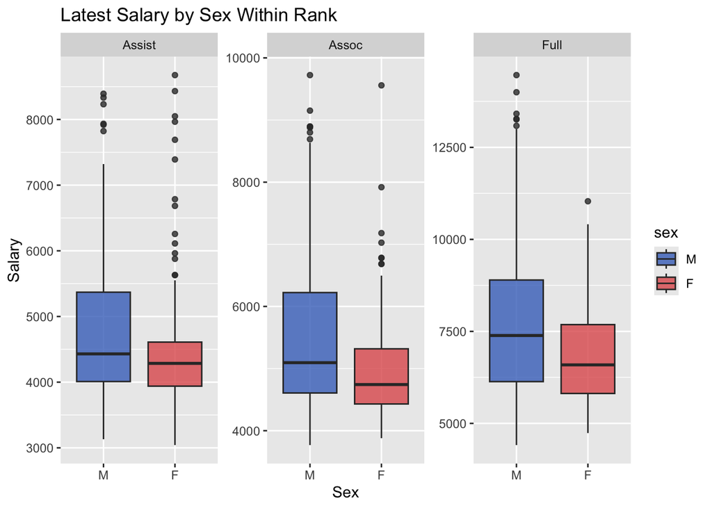

```r
ggplot(latest_salary, aes(x = sex, y = salary, fill = sex)) +
  geom_boxplot(alpha = 0.8) +
  scale_fill_manual(values = sex_colours) +
  facet_wrap(~ rank, scales = "free_y") +
  labs(
    title = "Latest Salary by Sex Within Rank",
    x = "Sex",
    y = "Salary"
  )
```

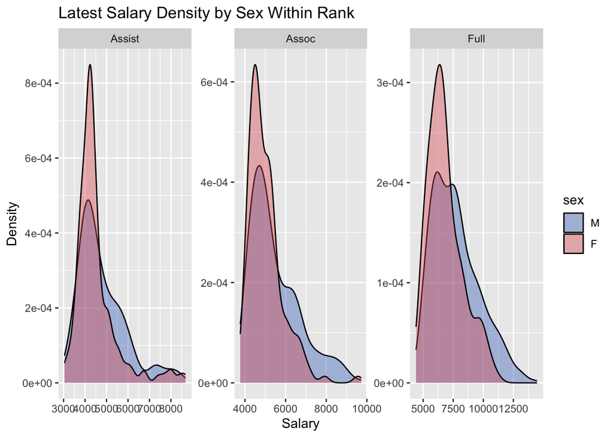

```r
ggplot(latest_salary, aes(x = salary, fill = sex)) +
  geom_density(alpha = 0.4) +
  scale_fill_manual(values = sex_colours) +
  facet_wrap(~ rank, scales = "free") +
  labs(
    title = "Latest Salary Density by Sex Within Rank",
    x = "Salary",
    y = "Density"
  )
```

```r
q3_lm <- lm(
  salary ~ sex + rank + field + experience + admin,
  data = latest_salary
)
cat("\nQ3 overall salary model (latest salary):\n")
```

```
##
## Q3 overall salary model (latest salary):
```

```r
summary(q3_lm)
```

```
##
## Call:
## lm(formula = salary ~ sex + rank + field + experience + admin,
##     data = latest_salary)
##
## Residuals:
##     Min      1Q  Median      3Q     Max
## -3334.3  -951.5  -164.3   600.3  6702.6
##
## Coefficients:
##             Estimate Std. Error t value Pr(>|t|)
## (Intercept) 4016.626    131.041  30.652  < 2e-16 ***
## sexF        -409.325     87.059  -4.702 2.80e-06 ***
## rankAssoc    600.365    113.938   5.269 1.56e-07 ***
## rankFull    2607.643    122.202  21.339  < 2e-16 ***
## fieldOther   781.297    106.729   7.320 3.91e-13 ***
## fieldProf   1769.944    128.711  13.751  < 2e-16 ***
## experience    -4.236      4.603  -0.920    0.358
## admin1      1202.224    118.822  10.118  < 2e-16 ***
## ---
## Signif. codes:  0 '***' 0.001 '**' 0.01 '*' 0.05 '.' 0.1 ' ' 1
##
## Residual standard error: 1431 on 1589 degrees of freedom
## Multiple R-squared:  0.5084, Adjusted R-squared:  0.5062
## F-statistic: 234.7 on 7 and 1589 DF,  p-value: < 2.2e-16
```

```r
cat("\nQ3 overall salary model with robust SE:\n")
```

```
##
## Q3 overall salary model with robust SE:
```

```r
coeftest(q3_lm, vcov = vcovHC(q3_lm, type = "HC1"))
```

```
##
## t test of coefficients:
##
##              Estimate Std. Error t value  Pr(>|t|)
## (Intercept) 4016.6261    88.3316 45.4721 < 2.2e-16 ***
## sexF        -409.3248    70.0167 -5.8461 6.095e-09 ***
## rankAssoc    600.3651    89.1285  6.7359 2.269e-11 ***
## rankFull    2607.6426   126.5920 20.5988 < 2.2e-16 ***
## fieldOther   781.2971    74.7331 10.4545 < 2.2e-16 ***
## fieldProf   1769.9444   108.0356 16.3830 < 2.2e-16 ***
## experience    -4.2364     5.6385 -0.7513    0.4526
## admin1      1202.2236   131.4548  9.1455 < 2.2e-16 ***
## ---
## Signif. codes:  0 '***' 0.001 '**' 0.01 '*' 0.05 '.' 0.1 ' ' 1
```

```r
# interaction model: does the salary gap differ by rank?
q3_interaction <- lm(
  salary ~ sex * rank + field + experience + admin,
  data = latest_salary
)
cat("\nQ3 salary model with sex x rank interaction:\n")
```

```
##
## Q3 salary model with sex x rank interaction:
```

```r
summary(q3_interaction)
```

```
##
## Call:
## lm(formula = salary ~ sex * rank + field + experience + admin,
##     data = latest_salary)
##
## Residuals:
##     Min      1Q  Median      3Q     Max
## -3374.8  -941.1  -187.9   594.1  6667.3
##
## Coefficients:
##                Estimate Std. Error t value Pr(>|t|)
## (Intercept)    3868.301    145.024  26.673  < 2e-16 ***
## sexF            -64.592    162.155  -0.398  0.69044
## rankAssoc       754.347    144.034   5.237 1.85e-07 ***
## rankFull       2817.331    143.439  19.641  < 2e-16 ***
## fieldOther      770.145    106.718   7.217 8.22e-13 ***
## fieldProf      1763.087    128.600  13.710  < 2e-16 ***
## experience       -4.811      4.598  -1.046  0.29565
## admin1         1205.407    118.575  10.166  < 2e-16 ***
## sexF:rankAssoc -314.264    218.627  -1.437  0.15079
## sexF:rankFull  -627.052    212.653  -2.949  0.00324 **
## ---
## Signif. codes:  0 '***' 0.001 '**' 0.01 '*' 0.05 '.' 0.1 ' ' 1
##
## Residual standard error: 1428 on 1587 degrees of freedom
## Multiple R-squared:  0.5111, Adjusted R-squared:  0.5083
## F-statistic: 184.3 on 9 and 1587 DF,  p-value: < 2.2e-16
```

```r
cat("\nQ3 interaction model with robust SE:\n")
```

```
##
## Q3 interaction model with robust SE:
```

```r
coeftest(q3_interaction, vcov = vcovHC(q3_interaction, type = "HC1"))
```

```
##
## t test of coefficients:
##
##                 Estimate Std. Error t value  Pr(>|t|)
## (Intercept)    3868.3009    99.7946 38.7626 < 2.2e-16 ***
## sexF            -64.5917   111.5342 -0.5791 0.5625900
## rankAssoc       754.3475   114.2743  6.6012 5.545e-11 ***
## rankFull       2817.3313   144.8704 19.4472 < 2.2e-16 ***
## fieldOther      770.1445    74.4327 10.3469 < 2.2e-16 ***
## fieldProf      1763.0873   108.0410 16.3187 < 2.2e-16 ***
## experience       -4.8107     5.6345 -0.8538 0.3933496
## admin1         1205.4075   130.8587  9.2115 < 2.2e-16 ***
## sexF:rankAssoc -314.2637   145.4078 -2.1613 0.0308246 *
## sexF:rankFull  -627.0516   172.1399 -3.6427 0.0002785 ***
## ---
## Signif. codes:  0 '***' 0.001 '**' 0.01 '*' 0.05 '.' 0.1 ' ' 1
```

```r
# log-salary
q3_lm_log <- lm(
  log_salary ~ sex + rank + field + experience + admin,
  data = latest_salary
)
cat("\nQ3 log-salary model:\n")
```

```
##
## Q3 log-salary model:
```

```r
summary(q3_lm_log)
```

```
##
## Call:
## lm(formula = log_salary ~ sex + rank + field + experience + admin,
##     data = latest_salary)
##
## Residuals:
##      Min       1Q   Median       3Q      Max
## -0.48818 -0.14113 -0.01492  0.11271  0.68607
##
## Coefficients:
##               Estimate Std. Error t value Pr(>|t|)
## (Intercept)  8.3226282  0.0182786 455.321  < 2e-16 ***
## sexF        -0.0590251  0.0121436  -4.861 1.29e-06 ***
## rankAssoc    0.1256876  0.0158930   7.908 4.84e-15 ***
## rankFull     0.4309180  0.0170457  25.280  < 2e-16 ***
## fieldOther   0.1200197  0.0148874   8.062 1.46e-15 ***
## fieldProf    0.2699668  0.0179535  15.037  < 2e-16 ***
## experience  -0.0003448  0.0006421  -0.537    0.591
## admin1       0.1670659  0.0165742  10.080  < 2e-16 ***
## ---
## Signif. codes:  0 '***' 0.001 '**' 0.01 '*' 0.05 '.' 0.1 ' ' 1
##
## Residual standard error: 0.1996 on 1589 degrees of freedom
## Multiple R-squared:  0.5678, Adjusted R-squared:  0.5659
## F-statistic: 298.2 on 7 and 1589 DF,  p-value: < 2.2e-16
```

```r
cat("\nQ3 log-salary model with robust SE:\n")
```

```
##
## Q3 log-salary model with robust SE:
```

```r
coeftest(q3_lm_log, vcov = vcovHC(q3_lm_log, type = "HC1"))
```

```
##
## t test of coefficients:
##
##                Estimate  Std. Error  t value  Pr(>|t|)
## (Intercept)  8.32262821  0.01424517 584.2420 < 2.2e-16 ***
## sexF        -0.05902512  0.01079013  -5.4703 5.212e-08 ***
## rankAssoc    0.12568758  0.01485859   8.4589 < 2.2e-16 ***
## rankFull     0.43091799  0.01811909  23.7825 < 2.2e-16 ***
## fieldOther   0.12001965  0.01133042  10.5927 < 2.2e-16 ***
## fieldProf    0.26996679  0.01490157  18.1167 < 2.2e-16 ***
## experience  -0.00034480  0.00071706  -0.4808    0.6307
## admin1       0.16706593  0.01594811  10.4756 < 2.2e-16 ***
## ---
## Signif. codes:  0 '***' 0.001 '**' 0.01 '*' 0.05 '.' 0.1 ' ' 1
```

```r
# coefs
q3_log_coef <- coef(q3_lm_log)["sexF"]
cat("\nApproximate percent difference for women in latest salary:\n")
```

```
##
## Approximate percent difference for women in latest salary:
```

```r
cat(round((exp(q3_log_coef) - 1) * 100, 2), "%\n")
```

```
## -5.73 %
```